# Reproducible Research Course: Peer Assessment Project 1

### v. Calculate and report the mean and median total number of steps taken per day. Do these values differ from the estimates from the first part of the assignment? What is the impact of imputing missing data on the estimates of the total daily number of steps?

```r
# Mean
mean(steps_Daily_New$steps)
```

```
## [1] 10765.64
```

```r
# Median
median(steps_Daily_New$steps)
```

```
## [1] 10762
```

### Are there differences in activity patterns between weekdays and weekends?

```r
# First of all create variable with date in correct format
activity_New$New_Date <- as.Date(activity_New$date, format = "%Y-%m-%d")
# Then, create a variable with weekday's name
activity_New$weekday <- weekdays(activity_New$New_Date)
# Finally, create a new variable indicating weekday or weekend
activity_New$Day_Type <- ifelse(activity_New$weekday=='Saturday' | activity_New$weekday=='Sunday', 'weekend','weekday')
# See the first 7 values
head(activity_New, 7)
```

```
##   steps interval       date   New_Date weekday Day_Type
## 1     2        0 2012-10-01 2012-10-01  Monday  weekday
## 2     0        5 2012-10-01 2012-10-01  Monday  weekday
## 3     0       10 2012-10-01 2012-10-01  Monday  weekday
## 4     0       15 2012-10-01 2012-10-01  Monday  weekday
## 5     0       20 2012-10-01 2012-10-01  Monday  weekday
## 6     2       25 2012-10-01 2012-10-01  Monday  weekday
## 7     1       30 2012-10-01 2012-10-01  Monday  weekday
```

### Make a panel plot containing a time series plot (i.e. type = “l”) of the 5-minute interval (x-axis) and the average number of steps taken, averaged across all weekday days or weekend days (y-axis)?

```r
# Create a table with steps per time across weekdays or weekends.
steps_Interval_Day_Type <- aggregate(steps~interval+Day_Type,data=activity_New,FUN=mean,na.action=na.omit)
# Verify new dataframe.
head(steps_Interval_Day_Type)
```

```
##   interval Day_Type      steps
## 1        0  weekday 2.28888889
## 2        5  weekday 0.40000000
## 3       10  weekday 0.15555556
## 4       15  weekday 0.17777778
## 5       20  weekday 0.08888889
## 6       25  weekday 1.57777778
```

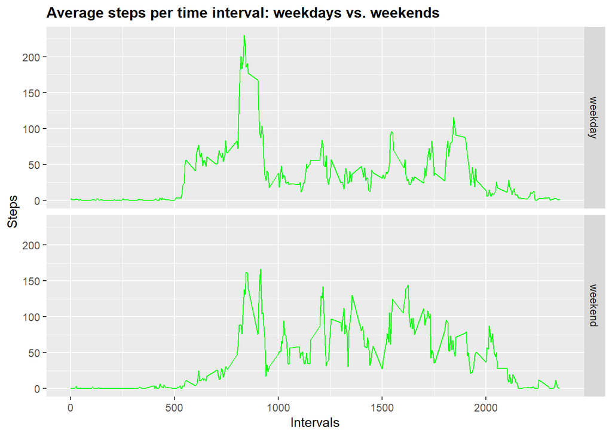

```r
# Add descriptive variables.
names(steps_Interval_Day_Type) <- c("interval", "Day_Type", "activity_Steps_Average")
# Draw the ggplot.
plot <- ggplot(steps_Interval_Day_Type, aes(interval, activity_Steps_Average))
plot+geom_line(col="green")+ggtitle("Average steps per time interval: weekdays vs. weekends")+xlab("Intervals")+ylab("Steps")+theme(plot.title = element_text(face="bold", size=12))+facet_grid(Day_Type ~ .)
```

**Conclusion: The plots appear similar in terms of activity patterns. However, there is a subtle difference with the weekday plot appearing to peak earlier than the one of the weekend.**